# Simple ANOVA tests for beech forest dynamics in NZ

Anth Davidson

2019-10-11

# 1 Overview

Generally this is the simple anova models for CR data using the first data chapter of my PhD as an example.

# 2 Introduction

At times of high and low abundance there is evidence that mice populations are likely to be under different population pressures. It has been shown that population level processes such as density dependance (competition between individuals for space or resources) when populations are at high abundance (Ruscoe et al. 2005). But at low abundance the demographic processes limiting populations are different, namely resource avaliability rather than competition (Choquenot and Ruscoe 2000). Because these two demographic processes are fundementally different we need to test these times independant of each other. We can then be sure that one phase/season is not obscurring the processes of the other.

## 2.1 Survey design

## 2.2 Simple visual summaries

### 2.2.1 Seeds

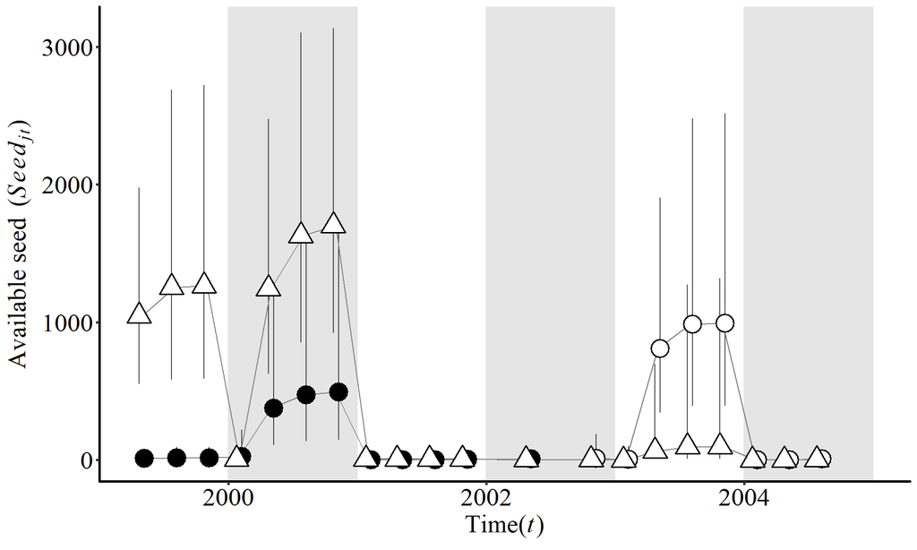

### 2.2.2 Mice

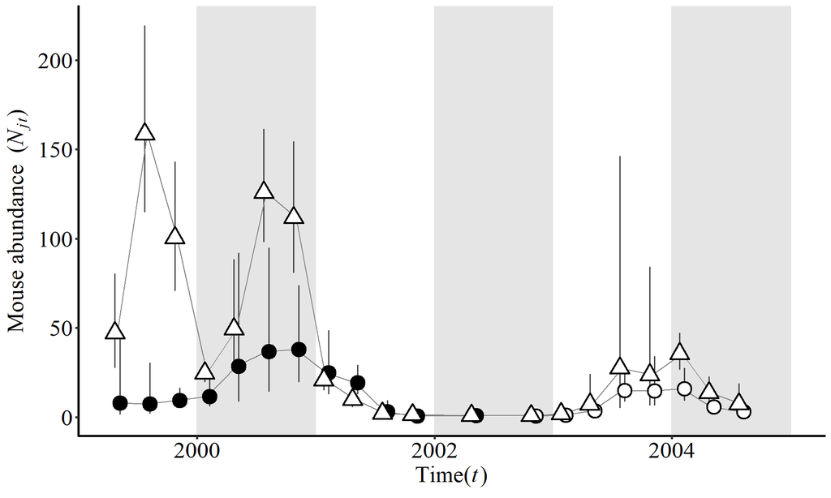

### 2.2.3 Rats

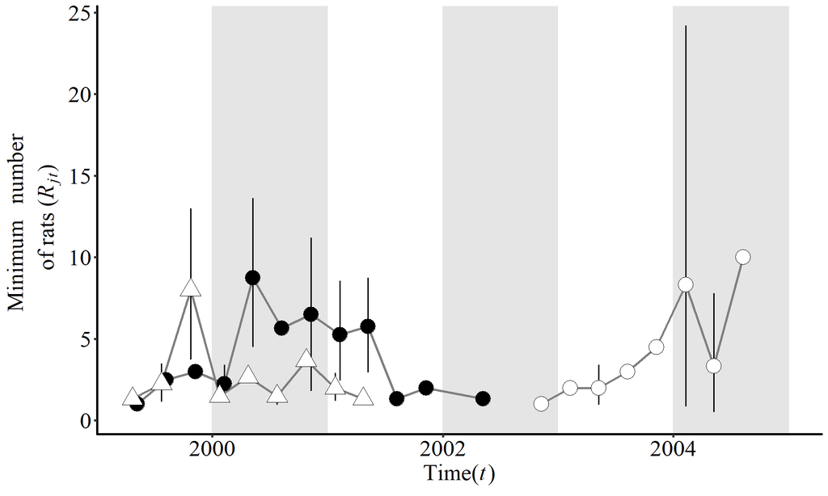

## 2.3 Data selection

Selecting the estimates in our dataset that incorperate the low and high prediction dynamics.

### 2.3.1 Low abundance

How to choose what groups to compare?

We have chosen to select trips 10 -> 15 as times of low abundance.

This dataset is generated from a combination of the modified data and uses the Bayesian model estimates of abundance but does not use any of the model coefficients currently.

Therefore we use the overall dataset including all $144$ replicates rather than the reduced $r_{j,t}$.

```r
# source("./Davidson_2019_Data_wrangling.R", echo = FALSE)
plot.dat.all1 <- read_csv("./data/plot-all-data1.csv")
# head(abund.dat5)
low.abund.dat <- plot.dat.all1 %>%
  # mutate(N = mean.lam) %>%  # for when using out.N
  filter(trip == 10 | trip == 11 | trip == 12 | trip == 13 | trip == 14 | trip == 15)
# filter(low.abund.dat, trip.no == 15)$true.date
```

We can summarise the data over valleys, control areas and/or treatments to compare the means and variances.

```r
# summary for plots
# create summarised datasets of need
low.cond.sum <- low.abund.dat %>%
  group_by(Control,Valley,Conditions) %>%
  summarise(N.count = n(),
            N = mean(N, rm.na = TRUE),
            tvalue = qt(p = 0.025, df = N.count - 1, lower.tail = FALSE),
            low.se = mean(se.N),
            lcl.low.tv = N - (tvalue*low.se),
            ucl.low.tv = N + (tvalue*low.se),
            lcl.low = N - (1.96*low.se),
            ucl.low = N + (1.96*low.se))

low.con <- low.abund.dat %>%
  group_by(Control)  %>%
  summarise(N.count = n(),
            N = mean(N, rm.na = TRUE),
            tvalue = qt(p = 0.025, df = N.count - 1, lower.tail = FALSE),
            low.se = mean(se.N),
            lcl.low.tv = N - (tvalue*low.se),
            ucl.low.tv = N + (tvalue*low.se),
            lcl.low = N - (1.96*low.se),
            ucl.low = N + (1.96*low.se))

low.con1 <- low.con %>%
              mutate(lcl.low = ifelse(lcl.low < 0, 0, lcl.low))
```

These comparisons would be fine but there are un-equal replicates and other issues that we need to account for using a ANOVA or mixed model.

### 2.3.2 High abundance

```r
# reduce to low abundance only data only
high.abund.dat <- plot.dat.all1 %>%
  filter(trip.no == 6 | trip.no == 7 | trip.no == 16 | trip.no == 17 )  %>%
  mutate(n.seed.l = N/log.seed,
         n.seed.c = N/cum.seed) %>%
  droplevels()  %>%
  mutate(n.seed.l = ifelse(n.seed.l > 10000 , 0, n.seed.l),
         n.seed.c = ifelse(n.seed.c > 10000 , 0, n.seed.c))
```

Summaries

```r
# summary for plots
# create summarised datasets of need
high.cond.sum <-  high.abund.dat %>%
  group_by(Control, Valley, Conditions) %>%
  summarise(N.count = n(),
            mean.seed.c = mean(n.seed.c, rm.na = TRUE),
            tvalue = qt(p = 0.025, df = N.count - 1),
            high.sd = sd(n.seed.c),
            high.se = sd(n.seed.c)/sqrt(N.count),
            lcl.high.tv = mean.seed.c - (tvalue* high.se),
            ucl.high.tv = mean.seed.c + (tvalue* high.se),
            lcl.high = mean.seed.c - (1.96* high.se),
            ucl.high = mean.seed.c + (1.96* high.se))

high.con <-  high.abund.dat %>%
  group_by(Control) %>%
  summarise(N.count = n(),
            mean.seed.c = mean(n.seed.c, rm.na = TRUE),
            tvalue = qt(p = 0.025, df = N.count - 1),
            high.sd = sd(n.seed.c),
            high.se = sd(n.seed.c)/sqrt(N.count),
            lcl.high.tv = mean.seed.c - (tvalue* high.se),
            ucl.high.tv = mean.seed.c + (tvalue* high.se),
            lcl.high = mean.seed.c - (1.96* high.se),
            ucl.high = mean.seed.c + (1.96* high.se))

test.dat.2 <- high.abund.dat %>%
  select(N, Valley, Control, Conditions, trip, grid, n.seed.c)

high.plot.avo <-   high.abund.dat %>%
  mutate(pt.pts = as.numeric(factor(paste(Valley, Control,Conditions))),
         pt.ft = factor(paste(valley, control, Conditions)),
         pt.ft.g2 = factor(paste(valley, control, Conditions)),
         valley = factor(valley, labels =  c("Eglinton", "Hollyford")),
         Conditions = factor(Conditions),
         control = factor(control))
```

Levels

```r
# names(high.plot.avo)
# factor(plot.dat2$pt.pts)
# factor(plot.dat2$pt.ft.g2)
levels(high.plot.avo$pt.ft.g2) <- c("egl control rats.present",
                                    "egl control rats.removed" ,
                                    "hol no control rats.present",
                                    "hol no control rats.removed",
                                    "hol control rats.present",
                                    "hol control rats.removed")

levels(high.plot.avo$pt.ft.g2) <- c(3,3,2,2,2,2)

# test.dat.1 <- high.abund.dat %>%
#   select(N, valley, control, Conditions, trip, grid, n.seed.c)
```

# 3 Methods and results

Using simple ANOVA methods for mixed models making the following assumptions:

1. Unequal variances
2. Unequal sample sizes
3. Non-independence removed
   - by partitioning groups by phase.
4. Seasons vary through time
   - phases don’t

## 3.2 Pa models

### 3.2.1 Control only

$$N = \beta_0 + \beta_1(control_i)$$

| Observations | 42 |
| --- | --- |
| Dependent variable | N |
| Type | Linear regression |

| χ²(1) | 0.32 |
| --- | --- |
| Pseudo-R² (Cragg-Uhler) | 0.00 |
| Pseudo-R² (McFadden) | 0.00 |
| AIC | 231.00 |
| BIC | 236.22 |

|  | Est. | S.E. | t val. | p |
| --- | --- | --- | --- | --- |
| (Intercept) | 2.35 | 1.04 | 2.25 | 0.03 |
| ControlYes | 0.19 | 1.23 | 0.16 | 0.88 |

Standard errors: MLE

[figure not shown]

### 3.2.2 Control and valley

And here is another model …

$$N = \beta_0 + \beta_1(control_i) + \beta_2(valley_i)$$

| Observations | 42 |
| --- | --- |
| Dependent variable | N |
| Type | Linear regression |

| χ²(2) | 3.25 |
| --- | --- |
| Pseudo-R² (Cragg-Uhler) | 0.01 |
| Pseudo-R² (McFadden) | 0.00 |
| AIC | 232.77 |
| BIC | 239.72 |

|  | Est. | S.E. | t val. | p |
| --- | --- | --- | --- | --- |
| (Intercept) | 3.03 | 1.79 | 1.69 | 0.10 |
| ControlYes | -0.28 | 1.61 | -0.18 | 0.86 |
| valleyhol | -0.68 | 1.45 | -0.47 | 0.64 |

Standard errors: MLE

[figure not shown]

### 3.2.3 Control, valley and conditions

And another one…
$$N = \beta_0 + \beta_1(control_i) + \beta_2(valley_i)+ \beta_3(Conditions_i)$$

| Observations | 42 |
| --- | --- |
| Dependent variable | N |
| Type | Linear regression |

| χ²(3) | 10.37 |
| --- | --- |
| Pseudo-R² (Cragg-Uhler) | 0.02 |
| Pseudo-R² (McFadden) | 0.00 |
| AIC | 234.19 |
| BIC | 242.88 |

|  | Est. | S.E. | t val. | p |
| --- | --- | --- | --- | --- |
| (Intercept) | 2.53 | 1.93 | 1.31 | 0.20 |
| ControlYes | -0.14 | 1.63 | -0.09 | 0.93 |
| ValleyHollyford | -0.60 | 1.47 | -0.41 | 0.68 |
| Conditionsrats.removed | 0.84 | 1.15 | 0.73 | 0.47 |

Standard errors: MLE

[figure not shown]

### 3.2.4 Log(N) main effects

$$log(N) = \beta_0 + \beta_1(control_i) + \beta_2(valley_i)+ \beta_3(Conditions_i)$$

| Observations | 42 |
| --- | --- |
| Dependent variable | log(N) |
| Type | Linear regression |

| χ²(3) | 2.28 |
| --- | --- |
| Pseudo-R² (Cragg-Uhler) | 0.07 |
| Pseudo-R² (McFadden) | 0.03 |
| AIC | 116.04 |
| BIC | 124.73 |

|  | Est. | S.E. | t val. | p |
| --- | --- | --- | --- | --- |
| (Intercept) | 0.25 | 0.47 | 0.53 | 0.60 |
| ControlYes | 0.13 | 0.40 | 0.32 | 0.75 |
| ValleyHollyford | -0.20 | 0.36 | -0.55 | 0.59 |
| Conditionsrats.removed | 0.39 | 0.28 | 1.37 | 0.18 |

Standard errors: MLE

[figure not shown]

| Observations | 42 |
| --- | --- |
| Dependent variable | N |
| Type | Linear regression |

| χ²(4) | 24.10 |
| --- | --- |
| Pseudo-R² (Cragg-Uhler) | 0.05 |
| Pseudo-R² (McFadden) | 0.01 |
| AIC | 235.05 |
| BIC | 245.47 |

|  | Est. | S.E. | t val. | p |
| --- | --- | --- | --- | --- |
| (Intercept) | 1.70 | 2.10 | 0.81 | 0.42 |
| ControlYes | 1.00 | 1.99 | 0.51 | 0.62 |
| ValleyHollyford | -0.67 | 1.47 | -0.46 | 0.65 |
| Conditionsrats.removed | 2.63 | 2.12 | 1.24 | 0.22 |
| ControlYes:Conditionsrats.removed | -2.55 | 2.52 | -1.01 | 0.32 |

Standard errors: MLE

[figure not shown]

| Observations | 42 |
| --- | --- |
| Dependent variable | log(N) |
| Type | Linear regression |

| χ²(4) | 2.48 |
| --- | --- |
| Pseudo-R² (Cragg-Uhler) | 0.08 |
| Pseudo-R² (McFadden) | 0.03 |
| AIC | 117.77 |
| BIC | 128.20 |

|  | Est. | S.E. | t val. | p |
| --- | --- | --- | --- | --- |
| (Intercept) | 0.15 | 0.52 | 0.30 | 0.77 |
| ControlYes | 0.26 | 0.49 | 0.53 | 0.60 |
| ValleyHollyford | -0.20 | 0.36 | -0.56 | 0.58 |
| Conditionsrats.removed | 0.60 | 0.52 | 1.14 | 0.26 |
| ControlYes:Conditionsrats.removed | -0.30 | 0.62 | -0.48 | 0.63 |

Standard errors: MLE

[figure not shown]

### 3.2.7 Full model (logged)

| Observations | 42 |
| --- | --- |
| Dependent variable | log(N) |
| Type | Linear regression |

| χ²(4) | 2.48 |
| --- | --- |
| Pseudo-R² (Cragg-Uhler) | 0.08 |
| Pseudo-R² (McFadden) | 0.03 |
| AIC | 117.77 |
| BIC | 128.20 |

|  | Est. | S.E. | t val. | p |
| --- | --- | --- | --- | --- |
| (Intercept) | 0.15 | 0.52 | 0.30 | 0.77 |
| ControlYes | 0.26 | 0.49 | 0.53 | 0.60 |
| ValleyHollyford | -0.20 | 0.36 | -0.56 | 0.58 |
| Conditionsrats.removed | 0.60 | 0.52 | 1.14 | 0.26 |
| ControlYes:Conditionsrats.removed | -0.30 | 0.62 | -0.48 | 0.63 |

Standard errors: MLE

[figure not shown]

## 3.3 Model selection

### 3.3.1 AIC

| mods.name | model.aic |
| --- | --- |
| low.mod1 | 231.0047 |
| low.mod2 | 232.7681 |
| low.mod3 | 234.1874 |

### 3.3.2 Other tests

| model.aic | mods.name | mod.dev |
| --- | --- | --- |
| 231.0047 | low.mod1 | 521.6763 |
| 232.7681 | low.mod2 | 518.7456 |
| 234.1874 | low.mod3 | 511.6225 |

## 3.4 Prediction B (high abundance)

## 3.5 Pb models

### 3.5.1 Control only

| Observations | 28 |
| --- | --- |
| Dependent variable | n.seed.c |
| Type | Linear regression |

| χ²(1) | 0.01 |
| --- | --- |
| Pseudo-R² (Cragg-Uhler) | -0.02 |
| Pseudo-R² (McFadden) | -0.03 |
| AIC | -9.93 |
| BIC | -5.93 |

|  | Est. | S.E. | t val. | p |
| --- | --- | --- | --- | --- |
| (Intercept) | 0.10 | 0.07 | 1.54 | 0.14 |
| ControlYes | 0.05 | 0.08 | 0.61 | 0.55 |

Standard errors: MLE

[figure not shown]

### 3.5.2 Control and Valley

| Observations | 28 |
| --- | --- |
| Dependent variable | n.seed.c |
| Type | Linear regression |

| χ²(2) | 0.15 |
| --- | --- |
| Pseudo-R² (Cragg-Uhler) | -0.22 |
| Pseudo-R² (McFadden) | -0.32 |
| AIC | -12.50 |
| BIC | -7.17 |

|  | Est. | S.E. | t val. | p |
| --- | --- | --- | --- | --- |
| (Intercept) | 0.29 | 0.11 | 2.67 | 0.01 |
| ControlYes | -0.08 | 0.10 | -0.83 | 0.42 |
| ValleyHollyford | -0.18 | 0.09 | -2.10 | 0.05 |

Standard errors: MLE

[output not shown]

[output not shown]

[output not shown]

Standard errors: MLE

[figure not shown]

### 3.5.3 Control, Valley and conditions

| Observations | 28 |
| --- | --- |
| Dependent variable | n.seed.c |
| Type | Linear regression |

| χ²(3) | 0.22 |
| --- | --- |
| Pseudo-R² (Cragg-Uhler) | -0.32 |
| Pseudo-R² (McFadden) | -0.48 |
| AIC | -13.01 |
| BIC | -6.35 |

|  | Est. | S.E. | t val. | p |
| --- | --- | --- | --- | --- |
| (Intercept) | 0.23 | 0.11 | 2.02 | 0.05 |
| ControlYes | -0.06 | 0.09 | -0.66 | 0.51 |
| ValleyHollyford | -0.17 | 0.08 | -2.04 | 0.05 |
| Conditionsrats.removed | 0.10 | 0.07 | 1.50 | 0.15 |

Standard errors: MLE

[output not shown]

[output not shown]

[output not shown]

Standard errors: MLE

[figure not shown]

### 3.5.4 Interaction between mice and rats

[output not shown]

[output not shown]

[output not shown]

Standard errors: MLE

[figure not shown]

### 3.5.5 Full model

| Observations | 28 |
| --- | --- |
| Dependent variable | n.seed.c |
| Type | Linear regression |

| χ²(3) | 0.10 |
| --- | --- |
| Pseudo-R² (Cragg-Uhler) | -0.14 |
| Pseudo-R² (McFadden) | -0.19 |
| AIC | -8.54 |
| BIC | -1.88 |

|  | Est. | S.E. | t val. | p |
| --- | --- | --- | --- | --- |
| (Intercept) | 0.05 | 0.09 | 0.52 | 0.61 |
| ControlYes | 0.06 | 0.11 | 0.53 | 0.60 |
| Conditionsrats.removed | 0.11 | 0.13 | 0.81 | 0.42 |
| ControlYes:Conditionsrats.removed | 0.00 | 0.16 | 0.02 | 0.98 |

Standard errors: MLE

[figure not shown]

## 3.6 Model selection

### 3.6.1 AIC

```
[1]  -9.930135 -12.497761 -13.008412
```

```
  mods.name model.aic
1 high.mod1  $-9.930$
2 high.mod2  $-12.50$
3 high.mod3  $-13.01$
```

### 3.6.2 Other tests

# 4 Applications

```
$serif
[1] "TT Times New Roman"

$sans
[1] "TT Arial"

$mono
[1] "TT Courier New"

$Times
[1] "TT Times New Roman"
```

Some *significant* applications are demonstrated in this chapter.

## 4.1 Publication one (black&white)

Results for first manuscript that need to be in black and white.

### 4.1.1 Low abundance

For the final low abundance model we have fitted the following Analysis of Variance

#### 4.1.1.1 Summary Pa

| Observations | 42 |
| --- | --- |
| Dependent variable | N |
| Type | Linear regression |

| χ²(4) | 24.10 |
| --- | --- |
| Pseudo-R² (Cragg-Uhler) | 0.05 |
| Pseudo-R² (McFadden) | 0.01 |
| AIC | 235.05 |
| BIC | 245.47 |

|  | Est. | S.E. | t val. | p |
| --- | --- | --- | --- | --- |
| (Intercept) | 1.70 | 2.10 | 0.81 | 0.42 |
| ControlYes | 1.00 | 1.99 | 0.51 | 0.62 |
| ValleyHollyford | -0.67 | 1.47 | -0.46 | 0.65 |
| Conditionsrats.removed | 2.63 | 2.12 | 1.24 | 0.22 |
| ControlYes:Conditionsrats.removed | -2.55 | 2.52 | -1.01 | 0.32 |

Standard errors: MLE

[figure not shown]

#### 4.1.1.2 Diagnostics Pa

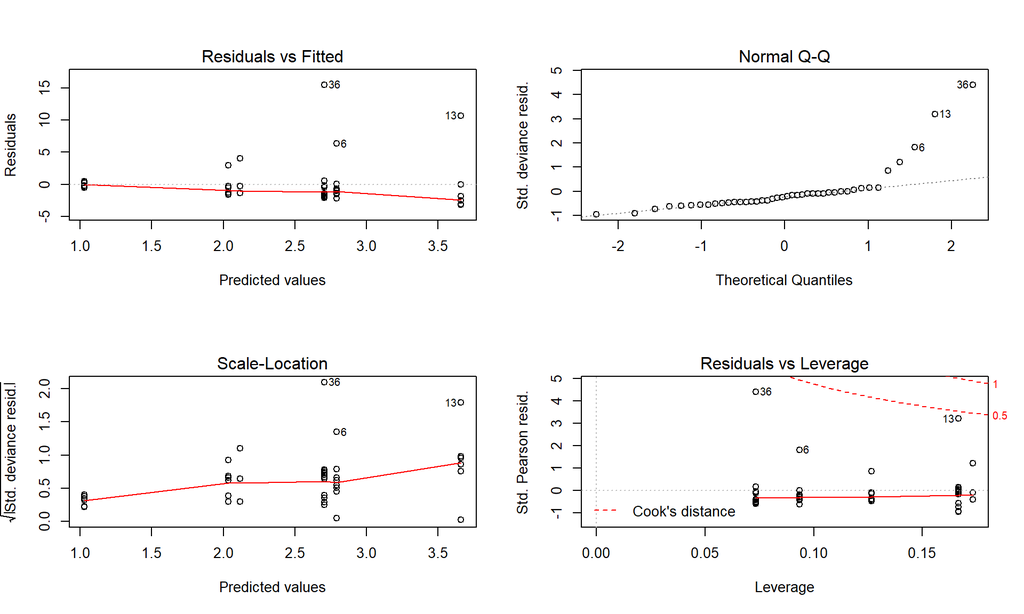

#### 4.1.1.3 Plot Pa

[figure not shown]

#### 4.1.1.4 Combined Pa

[figure not shown]

### 4.1.2 High abundance

The final model will be

`glm(n.seed.c ~ valley + control + Conditions + Conditions:control, family = "gaussian", data = high.abund.dat)`

#### 4.1.2.1 Summary Pb

```r
# reduce to low abundance only data only
high.abund.dat <- plot.dat.all1 %>%
  filter(trip.no == 6 | trip.no == 7 | trip.no == 16 | trip.no == 17 )  %>%
  mutate(n.seed.l = N/log.seed,
         n.seed.c = N/cum.seed) %>%
  droplevels()  %>%
  mutate(n.seed.l = ifelse(n.seed.l > 10000 , 0, n.seed.l),
         n.seed.c = ifelse(n.seed.c > 10000 , 0, n.seed.c))
# summary for plots
# create summarised datasets of need
high.cond.sum <-  high.abund.dat %>%
  group_by(Control, Valley, Conditions) %>%
  summarise(N.count = n(),
            mean.seed.c = mean(n.seed.c, rm.na = TRUE),
            tvalue = qt(p = 0.025, df = N.count - 1),
            high.sd = sd(n.seed.c),
            high.se = sd(n.seed.c)/sqrt(N.count),
            lcl.high.tv = mean.seed.c - (tvalue* high.se),
            ucl.high.tv = mean.seed.c + (tvalue* high.se),
            lcl.high = mean.seed.c - (1.96* high.se),
            ucl.high = mean.seed.c + (1.96* high.se))

high.con <-  high.abund.dat %>%
  group_by(Control, Valley) %>%
  summarise(N.count = n(),
            mean.seed.c = mean(n.seed.c, rm.na = TRUE),
            tvalue = qt(p = 0.025, df = N.count - 1),
            high.sd = sd(n.seed.c),
            high.se = sd(n.seed.c)/sqrt(N.count),
            lcl.high.tv = mean.seed.c - (tvalue* high.se),
            ucl.high.tv = mean.seed.c + (tvalue* high.se),
            lcl.high = mean.seed.c - (1.96* high.se),
            ucl.high = mean.seed.c + (1.96* high.se))

test.dat.2 <- high.abund.dat %>%
  select(N, Valley, Control, Conditions, trip, grid, n.seed.c)

high.plot.avo <-   high.abund.dat %>%
  mutate(pt.pts = as.numeric(factor(paste(Valley, Control,Conditions))),
         pt.ft = factor(paste(valley, control, Conditions)),
         pt.ft.g2 = factor(paste(valley, control, Conditions)),
         valley = factor(valley, labels =  c("Eglinton", "Hollyford")),
         Conditions = factor(Conditions),
         control = factor(control))

# names(high.plot.avo)
# factor(plot.dat2$pt.pts)
# factor(plot.dat2$pt.ft.g2)
levels(high.plot.avo$pt.ft.g2) <- c("egl control rats.present",
                                    "egl control rats.removed" ,
                                    "hol no control rats.present",
                                    "hol no control rats.removed",
                                    "hol control rats.present",
                                    "hol control rats.removed")

levels(high.plot.avo$pt.ft.g2) <- c(3,3,2,2,2,2)

# test.dat.1 <- high.abund.dat %>%
#   select(N, valley, control, Conditions, trip, grid, n.seed.c)

#high.mod3
high.mod3 <- glm(n.seed.c ~ valley + control + Conditions + Conditions:control, family = "gaussian", data = high.abund.dat)
summary.high.mod3 <- summary(high.mod3)
model.summary1 <- summary(high.mod3)

out.dens.high <-plot_summs(high.mod3, scale = TRUE, plot.distributions = TRUE, inner_ci_level = .9)
```

| Observations | 28 |
| --- | --- |
| Dependent variable | n.seed.c |
| Type | Linear regression |

| χ²(4) | 0.22 |
| --- | --- |
| Pseudo-R² (Cragg-Uhler) | -0.32 |
| Pseudo-R² (McFadden) | -0.48 |
| AIC | -11.02 |
| BIC | -3.02 |

|  | Est. | S.E. | t val. | p |
| --- | --- | --- | --- | --- |
| (Intercept) | 0.16 | 0.06 | 2.80 | 0.01 |
| valleyhol | -0.17 | 0.09 | -2.00 | 0.06 |
| controlno control | 0.06 | 0.12 | 0.49 | 0.63 |
| Conditionsrats.removed | 0.10 | 0.08 | 1.19 | 0.25 |
| controlno control:Conditionsrats.removed | 0.01 | 0.15 | 0.07 | 0.94 |

Standard errors: MLE

[figure not shown]

#### 4.1.2.2 Diagnostics Pb

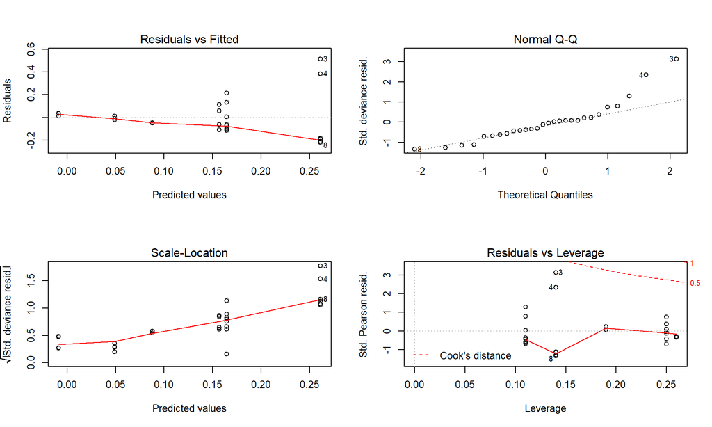

#### 4.1.2.3 Plots Pb

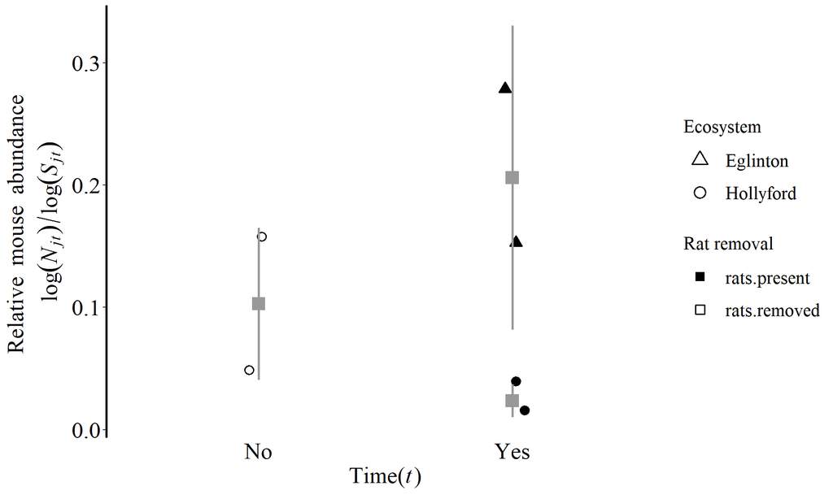

#### 4.1.2.4 Combined Pb

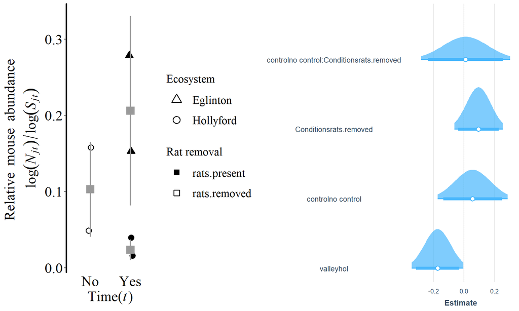

### 4.1.3 Save plots

Must be `png`

## 4.2 Thesis (colour)

Results for second chapter of thesis. The main difference in colour.

### 4.2.1 Low abundance

#### 4.2.1.1 Summary Pa

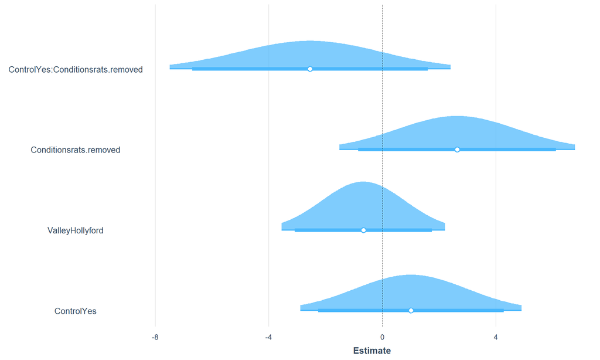

#### 4.2.1.2 Plot Pa

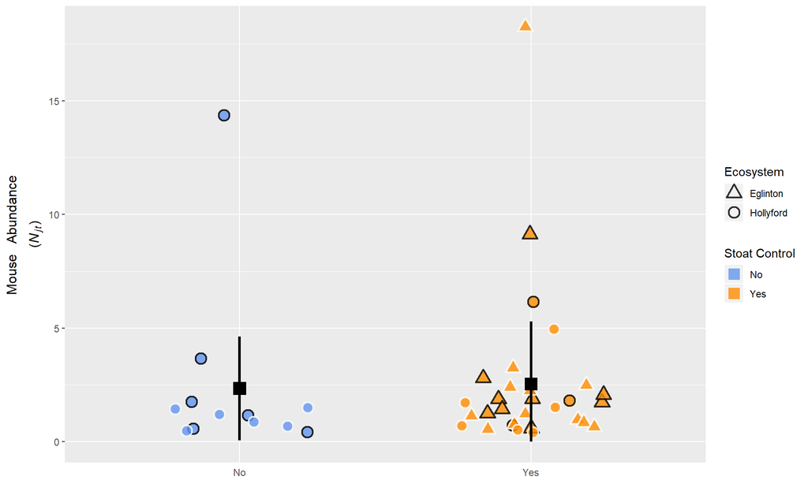

#### 4.2.1.3 Combined Pa

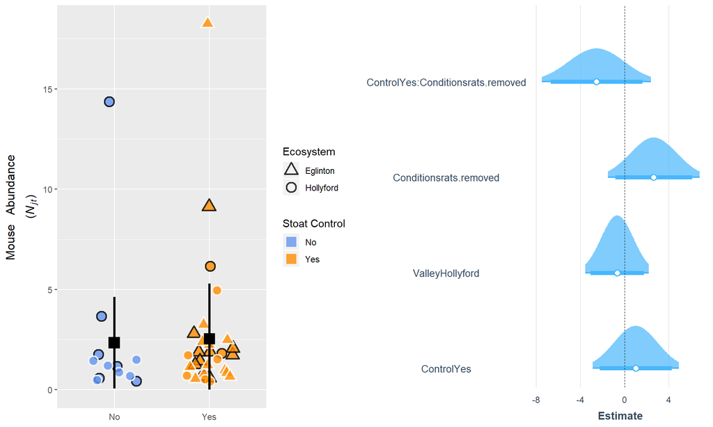

### 4.2.2 High abundance

#### 4.2.2.1 Summary Pb

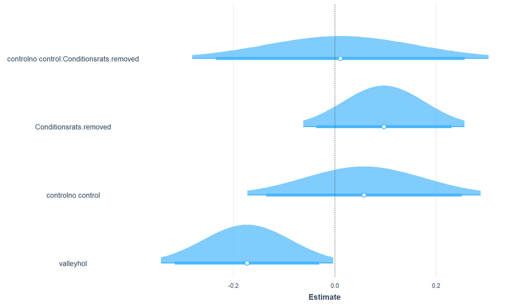

| Observations | 28 |
| --- | --- |
| Dependent variable | n.seed.c |
| Type | Linear regression |

| χ²(4) | 0.22 |
| --- | --- |
| Pseudo-R² (Cragg-Uhler) | -0.32 |
| Pseudo-R² (McFadden) | -0.48 |
| AIC | -11.02 |
| BIC | -3.02 |

|  | Est. | S.E. | t val. | p |
| --- | --- | --- | --- | --- |
| (Intercept) | 0.16 | 0.06 | 2.80 | 0.01 |
| valleyhol | -0.17 | 0.09 | -2.00 | 0.06 |
| controlno control | 0.06 | 0.12 | 0.49 | 0.63 |
| Conditionsrats.removed | 0.10 | 0.08 | 1.19 | 0.25 |
| controlno control:Conditionsrats.removed | 0.01 | 0.15 | 0.07 | 0.94 |

Standard errors: MLE

#### 4.2.2.2 Plots Pb

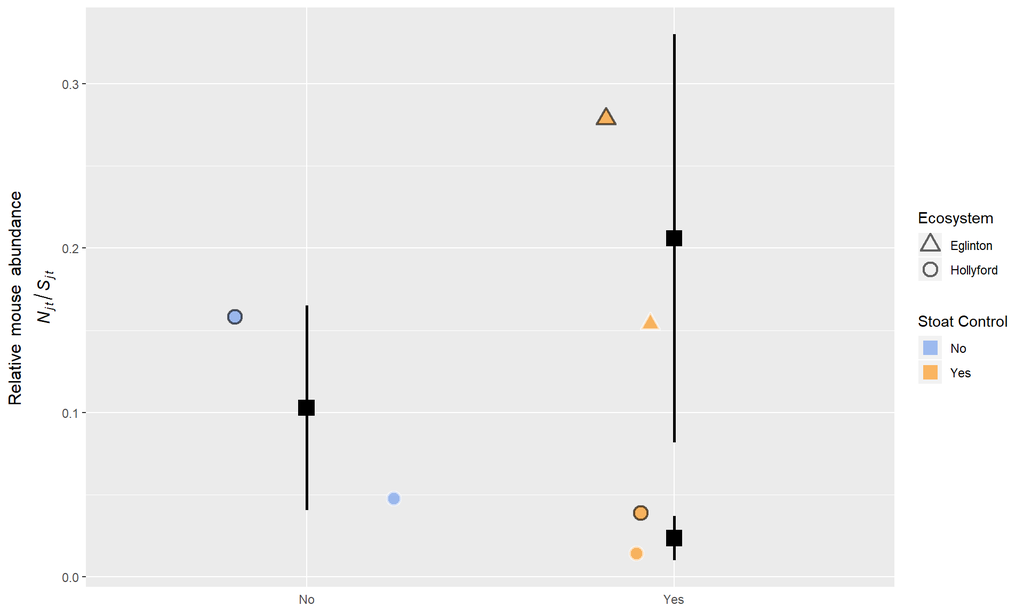

#### 4.2.2.3 Combined Pb

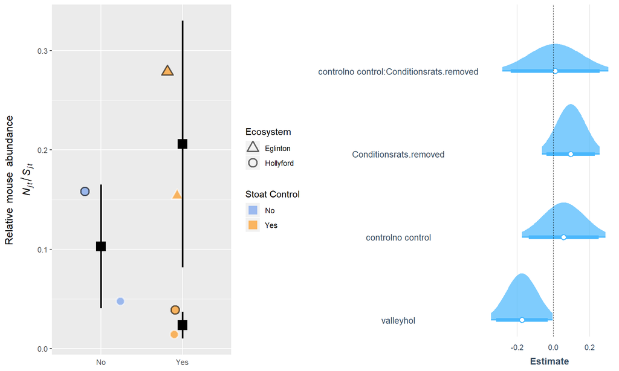

### 4.2.3 Save plots

Must be `png`

```r
# Low abundance
# export plot for example vignette
# png("./figs/fig-4-1.png")
png("C://Code/beech-publication-wr/figs/fig-4-1.png")
low.plot.time
dev.off()
```

```r
# png("./figs/fig-4-1-two.png")
png("C://Code/beech-publication-wr/figs/fig-4-1-two.png")
gridExtra::grid.arrange(low.plot.time, output.dens, ncol = 2)
dev.off()
```

```r
#High abundance
# export plot for example vignette
png("./figs/fig-4-2.png")
high.plot.time
dev.off()
```

```r
# export plot for example vignette
# png("../figs/fig-4-2-two.png")
png("C://Code/beech-publication-wr/figs/fig-4-2-two.png")
gridExtra::grid.arrange(high.plot.time, out.dens.high, ncol = 2)
dev.off()
```

# 5 Final Words

This is an interest set of analysis because it is somewhat post-hoc but ….

# References

Choquenot, David, and Wendy A Ruscoe. 2000. “Mouse Population Eruptions in New Zealand Forests: The Role of Population Density and Seedfall.” *Journal of Animal Ecology* 69: 1058–70.

Ruscoe, Wendy A, Joseph S Elkinton, David Choquenot, and Robert B Allen. 2005. “Predation of Beech Seed by Mice: Effects of Numerical and Functional Responses.” *Journal of Animal Ecology* 74: 1005–19. https://doi.org/10.1111/j.1365-2656.2005.00998.x.